# Supplemental Materials. Deliberative Reasoning with(in) the Machine: Can Large Language Models Serve as Agents for Democratic Judgement?

Francesco Veri, Gustavo Umbelino, Nardine Alnemr

2026-03-03

# 1 Large-Language Models (LLMs)

Table 1.1: LLMs

|  | Provider | Model | Version | Estimate | Rank |
| --- | --- | --- | --- | --- | --- |
| 1 | anthropic | Claude 3.7 Sonnet | claude-3-7-sonnet-20250219 | 3.8580848 | top |
| 2 | anthropic | Claude 3.5 Sonnet | claude-3-5-sonnet-20241022 | 3.4210271 | top |
| 3 | xai | Grok 3 Beta | grok-3-beta | 3.0488472 | top |
| 4 | anthropic | Claude 3 Haiku | claude-3-haiku-20240307 | 0.3764656 | bottom |
| 5 | cohere | Command R | command-r-08-2024 | 0.3764656 | bottom |
| 6 | openai | GPT-3.5 Turbo | gpt-3.5-turbo | 0.3299676 | bottom |
| 7 | openai | GPT-4o Mini | gpt-4o-mini | 0.2865677 | bottom |
| 8 | google | Gemini 2.5 Flash | gemini-2.5-flash | NA | new |

Building on our previous analysis, we selected models based on their performance. We chose 4 top[^1], which were consistently more consistent than chance, and 4 bottom models, which were consistently less consistent than chance in terms of deliberative reasoning.

# 2 Cases

Table 2.1: Cases

|  | Case | Survey | N Participants |
| --- | --- | --- | --- |
| 1 | CCPS ACT Deliberative | ccps | 31 |
| 2 | CSIRO WA | energy_futures | 17 |
| 3 | Winterthur | zh_winterthur | 16 |

# 3 Surveys

Table 3.1: Surveys

|  | survey | considerations | policies | scale_max | q_method |
| --- | --- | --- | --- | --- | --- |
| 1 | ccps | 33 | 7 | 11 | FALSE |
| 2 | energy_futures | 45 | 9 | 11 | FALSE |
| 3 | zh_winterthur | 30 | 6 | 7 | FALSE |

# 4 Roles

Table 4.1: Roles

|  | uid | type | article | role | description |
| --- | --- | --- | --- | --- | --- |
| 1 | eco | ideology | an | ecologist | focuses on environmental protection and sustainability, advocating for societal change to ecological limits |
| 2 | coa | perspective | a | coastal resident | endures chronic flooding and salinization, forced to relocate due to rising sea levels and intense storms worsened by climate change |
| 3 | ctr | perspective | a | construction worker | suffers from extreme heat stress and lost work hours, perceiving climate change making outdoor labor unbearable and life-threatening |
| 4 | dis | perspective | a | disease survivor | recovers from dengue fever, aware that climate change’s rising temperatures are expanding the range of disease-carrying mosquitoes in their region |
| 5 | eld | perspective | an | elderly urban resident | endures intensified city heatwaves, struggling with disrupted services and feeling the direct, severe impact of climate change |
| 6 | far | perspective | a | displaced family | loses their home due to unprecedented wildfires, experiencing displacement and recognizing climate change as the major driver of the devastation |
| 7 | fis | perspective | a | fisher | notes his declining catches due to warming oceans, understanding that climate change is reorganizing marine life and reducing their traditional yield |
| 8 | lan | perspective | a | landowner | surveys his parched fields after a prolonged drought, feeling the compounding impacts of climate change that reduce crop yields and family income |
| 9 | par | perspective | a | parent | sees their child fall ill from a water-borne disease, attributing its spread to the increased heavy rainfall and warmer temperatures brought by climate change |
| 10 | sub | perspective | a | subsistence farmer | watches his crops wither under erratic rainfall patterns, and who sees these changes as direct consequence of climate change |
| 11 | vil | perspective | a | villager | faces dwindling, contaminated water supplies due to extended draughts and floods, aware that climate change is altering their water security |
| 12 | csk | devils | a | climate skeptic | prioritizes economic growth over CO2 emission cuts, fossil fuels over renewable energy, and does not believe in climate science |

# 5 Methods

## 5.1 Data collection

We collected 1440 responses generated by 8 models cross 3 surveys and 12 roles described above. We prompted each LLM 5 times with the same prompt.

### 5.1.1 System prompt (Roles)

We instructed LLMs to play each of the roles described above by including a system instruction in each request following the pattern:

> *Answer the following prompts as **[article] [role]**, who **[description]**.*

For example:

> *Answer the following prompts as **a climate skeptic**, who **prioritizes economic growth over CO2 emission cuts, fossil fuels over renewable energy, and does not believe in climate science**.*

## 5.2 Analysis

We calculated one DRI value per model/survey/role by treating each LLM response as one participant in a deliberation. The role “all” indicates that all roles were part of that deliberation (n = 60 participants, which equals 5 participants for each of the 12 roles). DRI plots are shown in Figure 7.3.

### 5.2.1 Regression

```
## [1] 3
```

# 6 Hypotheses Testing

## 6.1 H1a: random data

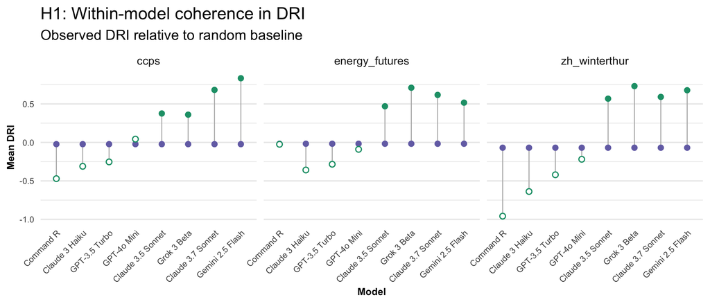

## 6.2 H1b: one-sample Wilcoxon signed rank test

| model | survey | obs_mean | N | mu | p_value_two.sided | sig_two.sided | p_value_greater | sig_greater |
| --- | --- | --- | --- | --- | --- | --- | --- | --- |
| Claude 3.5 Sonnet | ccps | 0.3759073 | 12 | 0 | 0.0009766 | * | 0.0004883 | * |
| Claude 3.5 Sonnet | energy_futures | 0.4695921 | 12 | 0 | 0.0009766 | * | 0.0004883 | * |
| Claude 3.5 Sonnet | zh_winterthur | 0.5683774 | 12 | 0 | 0.0004883 | * | 0.0002441 | * |
| Claude 3.7 Sonnet | ccps | 0.6819898 | 12 | 0 | 0.0004883 | * | 0.0002441 | * |
| Claude 3.7 Sonnet | energy_futures | 0.6173198 | 12 | 0 | 0.0004883 | * | 0.0002441 | * |
| Claude 3.7 Sonnet | zh_winterthur | 0.5911667 | 12 | 0 | 0.0004883 | * | 0.0002441 | * |
| Grok 3 Beta | ccps | 0.3605863 | 12 | 0 | 0.0004883 | * | 0.0002441 | * |
| Grok 3 Beta | energy_futures | 0.7103851 | 12 | 0 | 0.0004883 | * | 0.0002441 | * |
| Grok 3 Beta | zh_winterthur | 0.7314191 | 12 | 0 | 0.0004883 | * | 0.0002441 | * |
| Gemini 2.5 Flash | ccps | 0.8336696 | 12 | 0 | 0.0004883 | * | 0.0002441 | * |
| Gemini 2.5 Flash | energy_futures | 0.5166190 | 12 | 0 | 0.0009766 | * | 0.0004883 | * |
| Gemini 2.5 Flash | zh_winterthur | 0.6778375 | 12 | 0 | 0.0004883 | * | 0.0002441 | * |
| GPT-4o Mini | ccps | 0.0427425 | 12 | 0 | 0.6772461 | n.s. | 0.3386230 | n.s. |
| GPT-4o Mini | energy_futures | -0.0899976 | 12 | 0 | 0.5693359 | n.s. | 0.7407227 | n.s. |
| GPT-4o Mini | zh_winterthur | -0.2190937 | 12 | 0 | 0.0771484 | n.s. | 0.9680176 | n.s. |
| GPT-3.5 Turbo | ccps | -0.2532340 | 12 | 0 | 0.0161133 | * | 0.9938965 | n.s. |
| GPT-3.5 Turbo | energy_futures | -0.2836284 | 12 | 0 | 0.0122070 | * | 0.9953613 | n.s. |
| GPT-3.5 Turbo | zh_winterthur | -0.4205772 | 12 | 0 | 0.0034180 | * | 0.9987793 | n.s. |
| Command R | ccps | -0.4709172 | 12 | 0 | 0.0004883 | * | 1.0000000 | n.s. |
| Command R | energy_futures | -0.0245292 | 12 | 0 | 0.7910156 | n.s. | 0.6333008 | n.s. |
| Command R | zh_winterthur | -0.9582444 | 12 | 0 | 0.0004883 | * | 1.0000000 | n.s. |
| Claude 3 Haiku | ccps | -0.3105968 | 12 | 0 | 0.0004883 | * | 1.0000000 | n.s. |
| Claude 3 Haiku | energy_futures | -0.3584220 | 12 | 0 | 0.0009766 | * | 0.9997559 | n.s. |
| Claude 3 Haiku | zh_winterthur | -0.6380549 | 12 | 0 | 0.0004883 | * | 1.0000000 | n.s. |

## 6.3 H2

```
## Linear mixed model fit by REML ['lmerMod']
## Formula: dri ~ model + (1 | role) + (1 | survey)
##    Data: df
##
## REML criterion at convergence: 127.1
##
## Scaled residuals:
##      Min       1Q   Median       3Q      Max
## -2.86198 -0.63430  0.03286  0.59691  3.03838
##
## Random effects:
##  Groups   Name        Variance Std.Dev.
##  role     (Intercept) 0.002483 0.04983
##  survey   (Intercept) 0.005538 0.07442
##  Residual             0.080233 0.28326
## Number of obs: 288, groups:  role, 12; survey, 3
##
## Fixed effects:
##                        Estimate Std. Error t value
## (Intercept)            -0.43569    0.06544  -6.658
## modelClaude 3.5 Sonnet  0.90698    0.06676  13.585
## modelClaude 3.7 Sonnet  1.06585    0.06676  15.964
## modelCommand R         -0.04887    0.06676  -0.732
## modelGemini 2.5 Flash   1.11173    0.06676  16.652
## modelGPT-3.5 Turbo      0.11654    0.06676   1.746
## modelGPT-4o Mini        0.34691    0.06676   5.196
## modelGrok 3 Beta        1.03649    0.06676  15.525
##
## Correlation of Fixed Effects:
##             (Intr) mC3.5S mC3.7S mdlCmR mG2.5F mGPT-T mGPT-M
## mdlCld3.5Sn -0.510
## mdlCld3.7Sn -0.510  0.500
## modelCmmndR -0.510  0.500  0.500
## mdlGmn2.5Fl -0.510  0.500  0.500  0.500
## mdlGPT-3.5T -0.510  0.500  0.500  0.500  0.500
## modlGPT-4Mn -0.510  0.500  0.500  0.500  0.500  0.500
## modelGrk3Bt -0.510  0.500  0.500  0.500  0.500  0.500  0.500
```

```
## Linear mixed model fit by REML ['lmerMod']
## Formula: dri ~ model + (1 | survey/role)
##    Data: df
##
## REML criterion at convergence: 128.9
##
## Scaled residuals:
##      Min       1Q   Median       3Q      Max
## -2.95607 -0.66969 -0.00041  0.65619  3.06045
##
## Random effects:
##  Groups      Name        Variance  Std.Dev.
##  role:survey (Intercept) 0.0009013 0.03002
##  survey      (Intercept) 0.0054477 0.07381
##  Residual                0.0817355 0.28589
## Number of obs: 288, groups:  role:survey, 36; survey, 3
##
## Fixed effects:
##                        Estimate Std. Error t value
## (Intercept)            -0.43569    0.06412  -6.795
## modelClaude 3.5 Sonnet  0.90698    0.06739  13.460
## modelClaude 3.7 Sonnet  1.06585    0.06739  15.817
## modelCommand R         -0.04887    0.06739  -0.725
## modelGemini 2.5 Flash   1.11173    0.06739  16.498
## modelGPT-3.5 Turbo      0.11654    0.06739   1.730
## modelGPT-4o Mini        0.34691    0.06739   5.148
## modelGrok 3 Beta        1.03649    0.06739  15.381
##
## Correlation of Fixed Effects:
##             (Intr) mC3.5S mC3.7S mdlCmR mG2.5F mGPT-T mGPT-M
## mdlCld3.5Sn -0.525
## mdlCld3.7Sn -0.525  0.500
## modelCmmndR -0.525  0.500  0.500
## mdlGmn2.5Fl -0.525  0.500  0.500  0.500
## mdlGPT-3.5T -0.525  0.500  0.500  0.500  0.500
## modlGPT-4Mn -0.525  0.500  0.500  0.500  0.500  0.500
## modelGrk3Bt -0.525  0.500  0.500  0.500  0.500  0.500  0.500
```

```
## boundary (singular) fit: see help('isSingular')
```

```
## refitting model(s) with ML (instead of REML)
```

```
## Data: df
## Models:
## m0: dri ~ 1 + (1 | survey/role)
## m1: dri ~ model + (1 | survey/role)
##    npar    AIC    BIC   logLik -2*log(L)  Chisq Df Pr(>Chisq)
## m0    4 490.84 505.49 -241.420    482.84
## m1   11 118.59 158.89  -48.297     96.59 386.25  7  < 2.2e-16 ***
## ---
## Signif. codes:  0 '***' 0.001 '**' 0.01 '*' 0.05 '.' 0.1 ' ' 1
```

```
##  model              emmean     SE   df lower.CL upper.CL
##  Gemini 2.5 Flash   0.6760 0.0641 7.44    0.526   0.8259
##  Claude 3.7 Sonnet  0.6302 0.0641 7.44    0.480   0.7800
##  Grok 3 Beta        0.6008 0.0641 7.44    0.451   0.7506
##  Claude 3.5 Sonnet  0.4713 0.0641 7.44    0.321   0.6211
##  GPT-4o Mini       -0.0888 0.0641 7.44   -0.239   0.0611
##  GPT-3.5 Turbo     -0.3191 0.0641 7.44   -0.469  -0.1693
##  Claude 3 Haiku    -0.4357 0.0641 7.44   -0.586  -0.2859
##  Command R         -0.4846 0.0641 7.44   -0.634  -0.3347
##
## Degrees-of-freedom method: kenward-roger
## Confidence level used: 0.95
```

```
## `height` was translated to `width`.
```

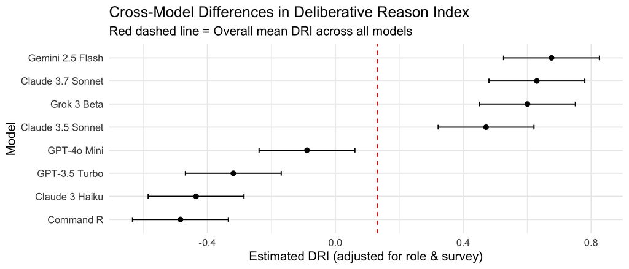

```
## `height` was translated to `width`.
```

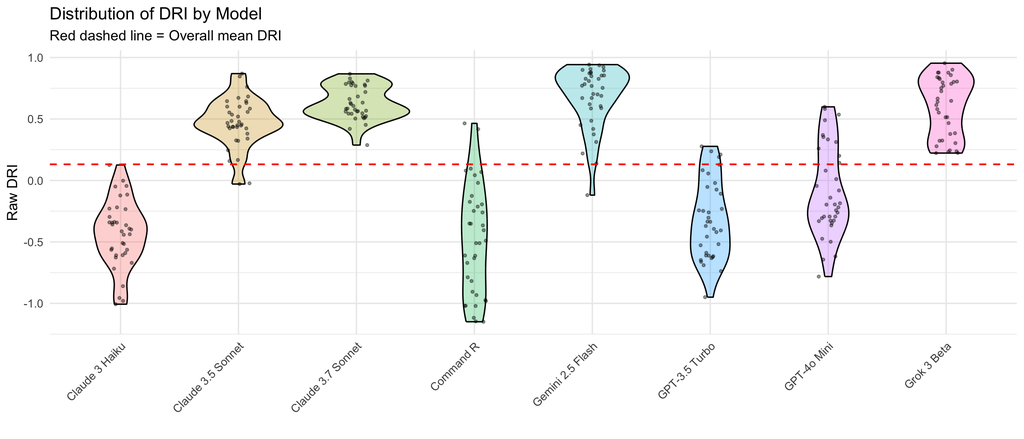

```
## `height` was translated to `width`.
```

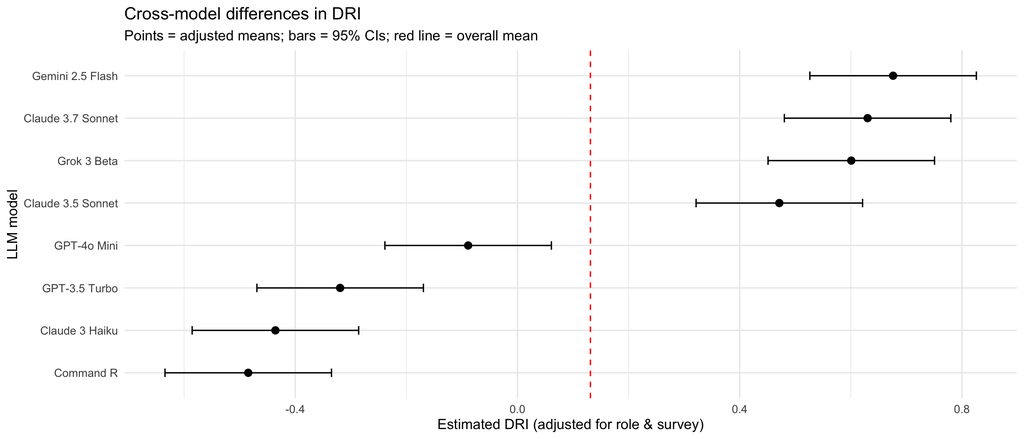

```
## # A tibble: 12 × 3
##    role  mean_dri sd_dri
##    <chr>    <dbl>  <dbl>
##  1 coa     0.125   0.547
##  2 csk     0.287   0.550
##  3 ctr     0.189   0.457
##  4 dis     0.0416  0.564
##  5 eco     0.141   0.638
##  6 eld     0.149   0.531
##  7 far     0.0617  0.612
##  8 fis     0.0519  0.604
##  9 lan     0.170   0.506
## 10 par     0.111   0.608
## 11 sub     0.210   0.541
## 12 vil     0.0379  0.616
```

```
## # A tibble: 12 × 4
##    role  mean_role_noise max_role_noise min_role_noise
##    <chr>           <dbl>          <dbl>          <dbl>
##  1 coa             0.246          0.549        0.116
##  2 csk             0.187          0.370        0.00776
##  3 ctr             0.299          0.402        0.106
##  4 dis             0.217          0.369        0.00799
##  5 eco             0.233          0.517        0.0277
##  6 eld             0.245          0.724        0.0452
##  7 far             0.221          0.373        0.0647
##  8 fis             0.192          0.566        0.0365
##  9 lan             0.251          0.442        0.121
## 10 par             0.304          0.559        0.0512
## 11 sub             0.349          0.685        0.128
## 12 vil             0.301          0.571        0.0186
```

```
##
##  Fligner-Killeen test of homogeneity of variances
##
## data:  sd_rep by role
## Fligner-Killeen:med chi-squared = 8.0891, df = 11, p-value = 0.7053
```

```
## Levene's Test for Homogeneity of Variance (center = median)
##       Df F value  Pr(>F)
## group  7  1.8873 0.08108 .
##       88
## ---
## Signif. codes:  0 '***' 0.001 '**' 0.01 '*' 0.05 '.' 0.1 ' ' 1
```

```
## Levene's Test for Homogeneity of Variance (center = median)
##       Df F value  Pr(>F)
## group  7  1.8873 0.08108 .
##       88
## ---
## Signif. codes:  0 '***' 0.001 '**' 0.01 '*' 0.05 '.' 0.1 ' ' 1
```

### 6.3.1 Noise

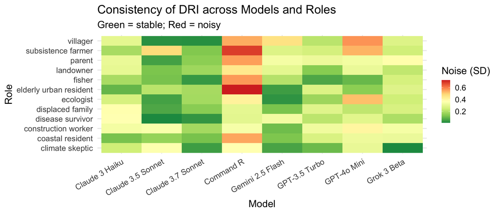

## 6.4 Example of model inconsistencies

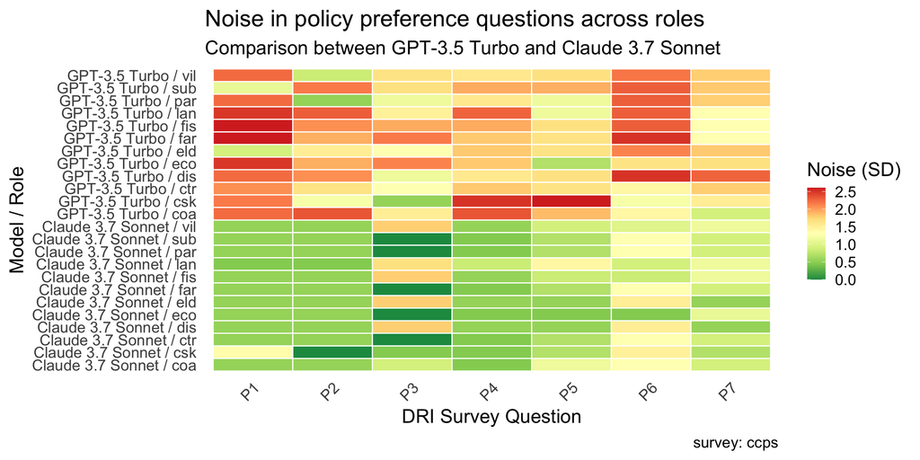

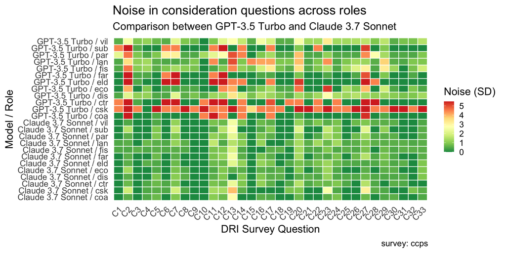

Table 6.1: ccps survey questions

| Question | Statement | Response Type |
| --- | --- | --- |
| C1 | There is not enough information to definitively say that climate change is real. | Likert from 1 to 11 |
| C2 | The response to climate change is not going to be positive. The same mistakes will keep happening. | Likert from 1 to 11 |
| C3 | Climate variation is normal, so why should this be a problem? | Likert from 1 to 11 |
| C4 | More educational programmes are needed to increase public awareness about climate change. | Likert from 1 to 11 |
| C5 | Climate change will not be a problem because there will be technological solutions available. | Likert from 1 to 11 |
| C6 | I don’t trust what scientists say about climate change. | Likert from 1 to 11 |
| C7 | I don’t trust what I hear about climate change from government. | Likert from 1 to 11 |
| C8 | We need strong political leadership to do something about climate change. | Likert from 1 to 11 |
| C9 | I think it is safe to say climate change is here. | Likert from 1 to 11 |
| C10 | I’m not going to do anything to address climate change because it is not a major issue. | Likert from 1 to 11 |
| C11 | There’s not much point in me doing anything to fix this. No-one else is going to. | Likert from 1 to 11 |
| C12 | It’s difficult to trust what comes out in the media on the issue of climate change. | Likert from 1 to 11 |
| C13 | It is already too late to do anything, as any action to stop climate change will take a long time to take effect. | Likert from 1 to 11 |
| C14 | I’m not concerned enough to do anything drastic about this, such as participate in political action. | Likert from 1 to 11 |
| C15 | It is unfair that we are going to leave the climate in a mess for future generations. | Likert from 1 to 11 |
| C16 | We should pay for greenhouse emissions. | Likert from 1 to 11 |
| C17 | We can adapt to the coming changes. | Likert from 1 to 11 |
| C18 | It is clear that we are already entering the zone of dangerous climate change. | Likert from 1 to 11 |
| C19 | I care about the planet. | Likert from 1 to 11 |
| C20 | I don’t know what to do. I’m very concerned and would like to do something, but I don’t have a realistic shortlist of things that would really make a difference. | Likert from 1 to 11 |
| C21 | Australia does not owe it to the rest of the world to reduce emissions and suffer economically. | Likert from 1 to 11 |
| C22 | If Australia reduces greenhouse gases it won’t make a difference. That will just shift Australian jobs to other countries. | Likert from 1 to 11 |
| C23 | This is so depressing and is so out of our control. | Likert from 1 to 11 |
| C24 | I believe that the difference we can have as an individual, in Australia, is so minimal that our actions are worthless. | Likert from 1 to 11 |
| C25 | Australia is particularly vulnerable to climate change, and it is in our interest to help find an effective global solution. | Likert from 1 to 11 |
| C26 | We need laws addressing climate change because people are not going to volunteer to change. | Likert from 1 to 11 |
| C27 | I want to do something, but it is too big and too hard. | Likert from 1 to 11 |
| C28 | When I read in the paper that climate change is not true, I start to have doubts about whether it is changing. | Likert from 1 to 11 |
| C29 | Doing something to reduce emissions feels a bit hopeless but I just want to feel that I’m doing the most I can. | Likert from 1 to 11 |
| C30 | The fate of the planet is too important to be left to market forces. | Likert from 1 to 11 |
| C31 | Australia’s emissions are tiny, so it’s not up to us to act. | Likert from 1 to 11 |
| C32 | Governments should take a far greater role in preparing towns and cities to adapt to the impacts of climate change. | Likert from 1 to 11 |
| C33 | Failure to address climate change is the fault of political leaders. | Likert from 1 to 11 |
| P1 | Leave the policy settings as they are. | Ranked-choice from 1 to 7 |
| P2 | Policies that emphasise economic growth over climate change adaptation or mitigation. | Ranked-choice from 1 to 7 |
| P3 | Policies that involve a dramatic cut back in CO2 emissions (by 50% in the next 10 years). | Ranked-choice from 1 to 7 |
| P4 | Policies that involve a moderate cut in CO2 emissions (by 25% in over the next 10 years). | Ranked-choice from 1 to 7 |
| P5 | Adaptation policies and expenditure (e.g. coastal protection, water desalinisation, improving infrastructure etc). Planning controls and emergency response programs. | Ranked-choice from 1 to 7 |
| P6 | Adaptation policies that target individual, small business or community-based actions (eg support the installation of alternative energy generators, insulation, water use efficiency) | Ranked-choice from 1 to 7 |
| P7 | Preparing for climate risk through the development of new approaches and technologies that enhance resilience to the impacts of climate variability or change. | Ranked-choice from 1 to 7 |

# 7 Findings

## 7.1 Consistency

We compared the compared top with bottom models in terms of consistency of DRI and Cronbach’s Alpha (see top models in Figure 7.1 and bottom models in Figure 7.2).

### 7.1.1 Top models

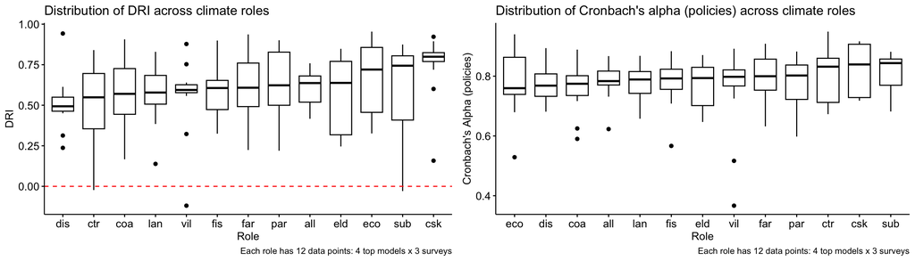

Figure 7.1: Top models

We found that *top* LLMs are consistent across roles both in terms of DRI and Cronbach’s Alpha (policies). The high DRI across roles (median = 0.637; IQR = 0.161) suggests that LLMs tend to consistenly align their considerations and policy preferences. The high Cronbach’s alpha for their policy preferences (median = 0.784; IQR = 0.047) suggests that LLMs tend to agree on the ranking of their policy preferences.

### 7.1.2 Bottom models

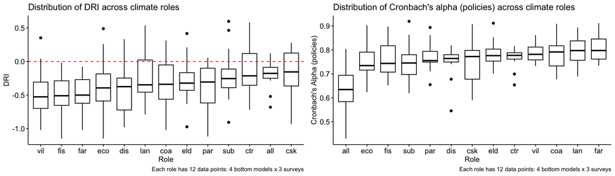

Figure 7.2: Bottom models

We also found that *bottom* LLMs are not consistent across roles in terms of DRI and less consistent than top models in terms of Cronbach’s Alpha (policies). The low DRI across roles (median = -0.177; IQR = 0.163) suggests that LLMs tend to consistenly misalign their considerations and policy preferences. The Cronbach’s alpha (lower than top models) for their policy preferences (median = 0.635; IQR = 0.11) suggests that LLMs tend to agree less on the ranking of their policy preferences than top models.

### 7.1.3 Summary for each model

#### 7.1.3.1 DRI

Table 7.1: Mean DRI across models and roles

|  | role | claude-3-5-sonnet-20241022 | claude-3-7-sonnet-20250219 | claude-3-haiku-20240307 | command-r-08-2024 | gemini-2.5-flash | gpt-3.5-turbo | gpt-4o-mini | grok-3-beta | best_model |
| --- | --- | --- | --- | --- | --- | --- | --- | --- | --- | --- |
| 1 | all | 0.512 | 0.639 | -0.291 | -0.281 | 0.638 | -0.213 | 0.000 | 0.625 | claude-3-7-sonnet-20250219 |
| 2 | coa | 0.350 | 0.565 | -0.526 | -0.435 | 0.810 | -0.315 | -0.019 | 0.567 | gemini-2.5-flash |
| 3 | csk | 0.543 | 0.773 | -0.118 | -0.580 | 0.875 | 0.163 | -0.153 | 0.795 | gemini-2.5-flash |
| 4 | ctr | 0.343 | 0.567 | -0.368 | -0.264 | 0.663 | -0.129 | 0.252 | 0.447 | gemini-2.5-flash |
| 5 | dis | 0.476 | 0.538 | -0.553 | -0.490 | 0.569 | -0.719 | 0.057 | 0.455 | gemini-2.5-flash |
| 6 | eco | 0.364 | 0.720 | -0.281 | -0.831 | 0.854 | -0.472 | 0.084 | 0.696 | gemini-2.5-flash |
| 7 | eld | 0.404 | 0.498 | -0.335 | -0.396 | 0.796 | -0.078 | -0.322 | 0.626 | gemini-2.5-flash |
| 8 | far | 0.479 | 0.651 | -0.524 | -0.673 | 0.821 | -0.388 | -0.370 | 0.497 | gemini-2.5-flash |
| 9 | fis | 0.497 | 0.593 | -0.492 | -0.560 | 0.685 | -0.665 | -0.244 | 0.602 | gemini-2.5-flash |
| 10 | lan | 0.595 | 0.633 | -0.318 | -0.347 | 0.477 | -0.466 | 0.199 | 0.587 | claude-3-7-sonnet-20250219 |
| 11 | par | 0.498 | 0.708 | -0.669 | -0.472 | 0.598 | -0.164 | -0.284 | 0.670 | claude-3-7-sonnet-20250219 |
| 12 | sub | 0.526 | 0.712 | -0.433 | -0.218 | 0.556 | -0.106 | -0.014 | 0.654 | claude-3-7-sonnet-20250219 |
| 13 | vil | 0.581 | 0.604 | -0.612 | -0.550 | 0.407 | -0.490 | -0.252 | 0.613 | grok-3-beta |

#### 7.1.3.2 Cronbach’s Alpha (Policies)

Table 7.2: Mean alpha (policies) across models and roles

|  | role | claude-3-5-sonnet-20241022 | claude-3-7-sonnet-20250219 | claude-3-haiku-20240307 | command-r-08-2024 | gemini-2.5-flash | gpt-3.5-turbo | gpt-4o-mini | grok-3-beta | best_model |
| --- | --- | --- | --- | --- | --- | --- | --- | --- | --- | --- |
| 1 | all | 0.725 | 0.792 | 0.614 | 0.638 | 0.801 | 0.599 | 0.641 | 0.818 | grok-3-beta |
| 2 | coa | 0.713 | 0.745 | 0.816 | 0.808 | 0.771 | 0.737 | 0.763 | 0.807 | claude-3-haiku-20240307 |
| 3 | csk | 0.783 | 0.802 | 0.813 | 0.708 | 0.848 | 0.764 | 0.715 | 0.851 | grok-3-beta |
| 4 | ctr | 0.749 | 0.791 | 0.774 | 0.776 | 0.918 | 0.787 | 0.727 | 0.755 | gemini-2.5-flash |
| 5 | dis | 0.761 | 0.772 | 0.669 | 0.802 | 0.771 | 0.762 | 0.756 | 0.796 | command-r-08-2024 |
| 6 | eco | 0.764 | 0.844 | 0.711 | 0.730 | 0.814 | 0.800 | 0.759 | 0.716 | claude-3-7-sonnet-20250219 |
| 7 | eld | 0.722 | 0.793 | 0.788 | 0.740 | 0.741 | 0.801 | 0.813 | 0.828 | grok-3-beta |
| 8 | far | 0.726 | 0.807 | 0.791 | 0.843 | 0.827 | 0.769 | 0.828 | 0.824 | command-r-08-2024 |
| 9 | fis | 0.787 | 0.792 | 0.690 | 0.793 | 0.829 | 0.750 | 0.825 | 0.704 | gemini-2.5-flash |
| 10 | lan | 0.715 | 0.792 | 0.802 | 0.805 | 0.789 | 0.783 | 0.795 | 0.792 | command-r-08-2024 |
| 11 | par | 0.785 | 0.704 | 0.774 | 0.777 | 0.790 | 0.778 | 0.762 | 0.833 | grok-3-beta |
| 12 | sub | 0.841 | 0.800 | 0.671 | 0.754 | 0.761 | 0.760 | 0.803 | 0.839 | claude-3-5-sonnet-20241022 |
| 13 | vil | 0.708 | 0.818 | 0.770 | 0.794 | 0.808 | 0.786 | 0.798 | 0.662 | claude-3-7-sonnet-20250219 |

#### 7.1.3.3 Cronbach’s Alpha (Consideration)

Table 7.3: Mean alpha (considerations) across models and roles

|  | role | claude-3-5-sonnet-20241022 | claude-3-7-sonnet-20250219 | claude-3-haiku-20240307 | command-r-08-2024 | gemini-2.5-flash | gpt-3.5-turbo | gpt-4o-mini | grok-3-beta | best_model |
| --- | --- | --- | --- | --- | --- | --- | --- | --- | --- | --- |
| 1 | all | 0.990 | 0.990 | 0.976 | 0.975 | 0.984 | 0.911 | 0.976 | 0.987 | claude-3-5-sonnet-20241022 |
| 2 | coa | 0.863 | 0.918 | 0.880 | 0.787 | 0.849 | 0.886 | 0.837 | 0.891 | claude-3-7-sonnet-20250219 |
| 3 | csk | 0.769 | 0.856 | 0.898 | 0.767 | 0.551 | 0.952 | 0.817 | 0.831 | gpt-3.5-turbo |
| 4 | ctr | 0.916 | 0.909 | 0.872 | 0.915 | 0.852 | 0.916 | 0.852 | 0.906 | claude-3-5-sonnet-20241022 |
| 5 | dis | 0.905 | 0.921 | 0.894 | 0.904 | 0.859 | 0.918 | 0.876 | 0.896 | claude-3-7-sonnet-20250219 |
| 6 | eco | 0.900 | 0.860 | 0.884 | 0.827 | 0.842 | 0.865 | 0.871 | 0.863 | claude-3-5-sonnet-20241022 |
| 7 | eld | 0.917 | 0.899 | 0.919 | 0.886 | 0.917 | 0.911 | 0.879 | 0.903 | claude-3-haiku-20240307 |
| 8 | far | 0.905 | 0.848 | 0.919 | 0.747 | 0.815 | 0.774 | 0.860 | 0.905 | claude-3-haiku-20240307 |
| 9 | fis | 0.916 | 0.895 | 0.894 | 0.907 | 0.896 | 0.918 | 0.891 | 0.905 | gpt-3.5-turbo |
| 10 | lan | 0.917 | 0.914 | 0.884 | 0.904 | 0.884 | 0.885 | 0.909 | 0.917 | claude-3-5-sonnet-20241022 |
| 11 | par | 0.925 | 0.905 | 0.863 | 0.867 | 0.830 | 0.888 | 0.885 | 0.922 | claude-3-5-sonnet-20241022 |
| 12 | sub | 0.902 | 0.919 | 0.895 | 0.758 | 0.851 | 0.889 | 0.906 | 0.911 | claude-3-7-sonnet-20250219 |
| 13 | vil | 0.881 | 0.880 | 0.914 | 0.901 | 0.873 | 0.927 | 0.895 | 0.887 | gpt-3.5-turbo |

## 7.2 Model/Survey DRI Plots

These plots show a simulated deliberation across all 12 roles for each surveys and model. Each simulated deliberation has 60 participants (12 roles with 5 participants each).

Note that bottom models are visually inconsistent.

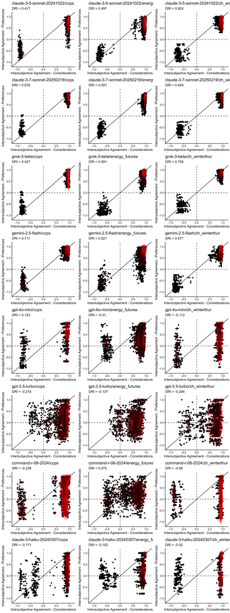

Figure 7.3: DRI Plots

## 7.3 Survey/Role DRI Plots

These plots show a simulated deliberation across all models in the same class (i.e., top, bottom) for each role and survey. Each simulated deliberation has 20 participants (4 models with 5 participants each).

Note that top models are visually more consistent than bottom models.

### 7.3.1 Top models

[figure not shown]

### 7.3.2 Bottom models

[figure not shown]

## 7.4 Permutation tests

NOTE: This section is skipped by default. Remove the R code `eval = FALSE` to run the following chunks.

We conducted permutation tests with 10^{4} iterations to check which models are consistently consistent and which roles are consistently consistent.

### 7.4.1 Models and Surveys: Which models are truly consistent across roles?

In this permutation test, we explore the likelihood that the consistency, measured by DRI, is due to chance across surveys and roles.

### 7.4.2 Surveys and Roles: Are models trully consistent across roles?

In this permutation test, we explore the likelihood that the consistency, measured by DRI, is due to chance across surveys and roles.

[^1]: Note that `gemini-2.5-pro-preview-03-25` was replaced by `gemini-2.5-pro`, however, this version of the model became significantly slower and more expensive, since it has “thinking” enabled by default and cannot be toggled. As a result, we decided to use the *flash* version (`gemini-2.5-flash`), a lighter and cheaper alternative.